# Economic and Health Impacts of US Severe Weather

Abdelrahman

2022-09-25

# Synopsis

In this project, we analyze the storm database taken from the U.S. National Oceanic and Atmospheric Administration (NOAA). We estimate the fatalities, injuries, property damage, and crop damage for each type of event (e.g., Flood, Typhoon, Tornado, Hail, Hurricane, etc.). Our goal is to determine which event is most harmful to US population (health) and which event has the largest economic consequences. Our analysis on Fatalities and Injuries conclude that **Tornado** is the **most harmful** event in respect to the **US Population Health**. On the other hand, based on the Property and Cost damage, we conclude that **Flood** has the **greatest economic consequences** to the US.

# Introduction

Storms and other severe weather events can cause both public health and economic problems for communities and municipalities. Many severe events can result in fatalities, injuries, and property damage, and preventing such outcomes to the extent possible is a key concern.

This project involves exploring the U.S. National Oceanic and Atmospheric Administration’s (NOAA) storm database. This database tracks characteristics of major storms and weather events in the United States, including when and where they occur, as well as estimates of any fatalities, injuries, and property damage.

# Questions

The data analysis address the following questions:

- Across the United States, which types of events are most harmful with respect to population health?
- Across the United States, which types of events have the greatest economic consequences?

# Data

- [Storm Data](https://d396qusza40orc.cloudfront.net/repdata%2Fdata%2FStormData.csv.bz2)
- National Weather Service [Storm Data Documentation](https://d396qusza40orc.cloudfront.net/repdata%2Fpeer2_doc%2Fpd01016005curr.pdf)
- National Climatic Data Center Storm Events [FAQ](https://d396qusza40orc.cloudfront.net/repdata%2Fpeer2_doc%2FNCDC%20Storm%20Events-FAQ%20Page.pdf)

The events in the database start in the year 1950 and end in November 2011. In the earlier years of the database there are generally fewer events recorded, most likely due to a lack of good records. More recent years should be considered more complete.

# Data Processing

```r
#load libraries
library(tidyr)
library(dplyr)
```

```r
library(readr)
library(ggplot2)
# To combine the different plots, in one multiplot.
library(gridExtra)
# set data in your working directory
# read data
storm_data <- read.csv("repdata_data_StormData.csv")
dim(storm_data)
```

```
## [1] 902297     37
```

```r
str(storm_data)
```

```
## 'data.frame':    902297 obs. of  37 variables:
##  $ STATE__   : num  1 1 1 1 1 1 1 1 1 1 ...
##  $ BGN_DATE  : chr  "4/18/1950 0:00:00" "4/18/1950 0:00:00" "2/20/1951 0:00:00" "6/8/1951 0:00:00" ...
##  $ BGN_TIME  : chr  "0130" "0145" "1600" "0900" ...
##  $ TIME_ZONE : chr  "CST" "CST" "CST" "CST" ...
##  $ COUNTY    : num  97 3 57 89 43 77 9 123 125 57 ...
##  $ COUNTYNAME: chr  "MOBILE" "BALDWIN" "FAYETTE" "MADISON" ...
##  $ STATE     : chr  "AL" "AL" "AL" "AL" ...
##  $ EVTYPE    : chr  "TORNADO" "TORNADO" "TORNADO" "TORNADO" ...
##  $ BGN_RANGE : num  0 0 0 0 0 0 0 0 0 0 ...
##  $ BGN_AZI   : chr  "" "" "" "" ...
##  $ BGN_LOCATI: chr  "" "" "" "" ...
##  $ END_DATE  : chr  "" "" "" "" ...
##  $ END_TIME  : chr  "" "" "" "" ...
##  $ COUNTY_END: num  0 0 0 0 0 0 0 0 0 0 ...
```

[output cut: 23 more lines]

```r
head(storm_data)
```

```
##   STATE__           BGN_DATE BGN_TIME TIME_ZONE COUNTY COUNTYNAME STATE  EVTYPE
## 1       1  4/18/1950 0:00:00     0130       CST     97     MOBILE    AL TORNADO
## 2       1  4/18/1950 0:00:00     0145       CST      3    BALDWIN    AL TORNADO
## 3       1  2/20/1951 0:00:00     1600       CST     57    FAYETTE    AL TORNADO
## 4       1   6/8/1951 0:00:00     0900       CST     89    MADISON    AL TORNADO
## 5       1 11/15/1951 0:00:00     1500       CST     43    CULLMAN    AL TORNADO
## 6       1 11/15/1951 0:00:00     2000       CST     77 LAUDERDALE    AL TORNADO
##   BGN_RANGE BGN_AZI BGN_LOCATI END_DATE END_TIME COUNTY_END COUNTYENDN
## 1         0                                               0         NA
## 2         0                                               0         NA
## 3         0                                               0         NA
## 4         0                                               0         NA
## 5         0                                               0         NA
## 6         0                                               0         NA
##   END_RANGE END_AZI END_LOCATI LENGTH WIDTH F MAG FATALITIES INJURIES PROPDMG
```

[output cut: 20 more lines]

```r
# check for NAs
sum(is.na(storm_data$CROPDMGEXP))
```

```
## [1] 0
```

```r
sum(is.na(storm_data$PROPDMGEXP))
```

```
## [1] 0
```

```r
sum(is.na(storm_data$CROPDMG))
```

```
## [1] 0
```

```r
sum(is.na(storm_data$PROPDMG))
```

```
## [1] 0
```

```r
sum(is.na(storm_data$EVTYPE))
```

```
## [1] 0
```

```r
# select variable we need
variables <- c("EVTYPE","FATALITIES","INJURIES","PROPDMG","PROPDMGEXP","CROPDMG","CROPDMGEXP")
storm_data <-  storm_data[,(names(storm_data) %in% variables)]
# make our events as factor
storm_data$EVTYPE <- as.factor(storm_data$EVTYPE)
str(storm_data)
```

```
## 'data.frame':    902297 obs. of  7 variables:
##  $ EVTYPE    : Factor w/ 985 levels "   HIGH SURF ADVISORY",..: 834 834 834 834 834 834 834 834 834 834 ...
##  $ FATALITIES: num  0 0 0 0 0 0 0 0 1 0 ...
##  $ INJURIES  : num  15 0 2 2 2 6 1 0 14 0 ...
##  $ PROPDMG   : num  25 2.5 25 2.5 2.5 2.5 2.5 2.5 25 25 ...
##  $ PROPDMGEXP: chr  "K" "K" "K" "K" ...
##  $ CROPDMG   : num  0 0 0 0 0 0 0 0 0 0 ...
##  $ CROPDMGEXP: chr  "" "" "" "" ...
```

```r
head(storm_data)
```

```
##    EVTYPE FATALITIES INJURIES PROPDMG PROPDMGEXP CROPDMG CROPDMGEXP
## 1 TORNADO          0       15    25.0          K       0
## 2 TORNADO          0        0     2.5          K       0
## 3 TORNADO          0        2    25.0          K       0
## 4 TORNADO          0        2     2.5          K       0
## 5 TORNADO          0        2     2.5          K       0
## 6 TORNADO          0        6     2.5          K       0
```

## Across the United States, which types of events (as indicated in the EVTYPE variable) are most harmful with respect to population health?

```r
#  first let's look at injuries to see most affected events
injuries<-storm_data %>% group_by(EVTYPE) %>% summarise(total=sum(INJURIES)) %>% arrange(desc(total))
head(injuries)
```

```
## # A tibble: 6 × 2
##   EVTYPE         total
##   <fct>          <dbl>
## 1 TORNADO        91346
## 2 TSTM WIND       6957
## 3 FLOOD           6789
## 4 EXCESSIVE HEAT  6525
## 5 LIGHTNING       5230
## 6 HEAT            2100
```

```r
str(injuries)
```

```
## tibble [985 × 2] (S3: tbl_df/tbl/data.frame)
##  $ EVTYPE: Factor w/ 985 levels "   HIGH SURF ADVISORY",..: 834 856 170 130 464 275 427 153 760 244 ...
##  $ total : num [1:985] 91346 6957 6789 6525 5230 ...
```

you can go to [STORM DATA PREPARATION](https://d396qusza40orc.cloudfront.net/repdata%2Fpeer2_doc%2Fpd01016005curr.pdf) to know how we choose our events labels as we see that there is typo so i ’ll try to fix it to make the first high rank events more accurate.

```r
# we need to do some fix in events name
storm_data$EVTYPE <- gsub("THUNDERSTORM WIND", "TSTM WIND", storm_data$EVTYPE)
storm_data$EVTYPE <- gsub("THUNDERSTORM WINDS", "TSTM WIND", storm_data$EVTYPE)
storm_data$EVTYPE <- gsub("TSTM WINDS", "TSTM WIND", storm_data$EVTYPE)
storm_data$EVTYPE <- gsub("HIGH WINDS", "HIGH WIND", storm_data$EVTYPE)
storm_data$EVTYPE <- gsub("ICE", "ICE STORM", storm_data$EVTYPE)
storm_data$EVTYPE <- gsub("FOG", "FREEZING FOG", storm_data$EVTYPE)
storm_data$EVTYPE <- gsub("FREEZING FREEZING FOG", "FREEZING FOG", storm_data$EVTYPE)
storm_data$EVTYPE <- gsub("DENSE FREEZING FOG", "DENSE FOG", storm_data$EVTYPE)
storm_data$EVTYPE <- gsub("HEAT WAVE", "HEAT", storm_data$EVTYPE)
storm_data$EVTYPE <- gsub("Heat Wave", "HEAT", storm_data$EVTYPE)
storm_data$EVTYPE <- gsub("EXTREME HEAT", "HEAT", storm_data$EVTYPE)
storm_data$EVTYPE <- gsub("ICE STORM STORM", "ICE STORM", storm_data$EVTYPE)
storm_data$EVTYPE <- gsub("WILD/FOREST FIRE", "WILDFIRE", storm_data$EVTYPE)
storm_data$EVTYPE <- gsub("HURRICANE", "HURRICANE/TYPHOON", storm_data$EVTYPE)
storm_data$EVTYPE <- gsub("HURRICANE/TYPHOON/TYPHOON", "HURRICANE/TYPHOON", storm_data$EVTYPE)

# after editing names of events
storm_data$EVTYPE <- as.factor(storm_data$EVTYPE)

# try it now, more better right!!
injuries<-storm_data %>% group_by(EVTYPE) %>% summarise(total_injuries=sum(INJURIES)) %>% arrange(desc(total_injuries))
injuries$type <- "injuries"
injuries$type <- as.factor(injuries$type)
str(injuries)
```

```
## tibble [952 × 3] (S3: tbl_df/tbl/data.frame)
##  $ EVTYPE        : Factor w/ 952 levels "   HIGH SURF ADVISORY",..: 759 781 169 130 450 272 407 152 925 350 ...
##  $ total_injuries: num [1:952] 91346 9353 6789 6525 5230 ...
##  $ type          : Factor w/ 1 level "injuries": 1 1 1 1 1 1 1 1 1 1 ...
```

```r
head(injuries,5)
```

```
## # A tibble: 5 × 3
##   EVTYPE         total_injuries type
##   <fct>                   <dbl> <fct>
## 1 TORNADO                 91346 injuries
## 2 TSTM WIND                9353 injuries
## 3 FLOOD                    6789 injuries
## 4 EXCESSIVE HEAT           6525 injuries
## 5 LIGHTNING                5230 injuries
```

```r
# look at fatalities
fatalities<-storm_data %>% group_by(EVTYPE) %>% summarise(total_fatalities=sum(FATALITIES)) %>% arrange(desc(total_fatalities))
fatalities$type <- "fatalities"
fatalities$type <- as.factor(fatalities$type)
str(fatalities)
```

```
## tibble [952 × 3] (S3: tbl_df/tbl/data.frame)
##  $ EVTYPE          : Factor w/ 952 levels "   HIGH SURF ADVISORY",..: 759 130 272 152 450 781 169 569 350 19 ...
##  $ total_fatalities: num [1:952] 5633 1903 1205 978 816 ...
##  $ type            : Factor w/ 1 level "fatalities": 1 1 1 1 1 1 1 1 1 1 ...
```

```r
head(fatalities,5)
```

```
## # A tibble: 5 × 3
##   EVTYPE         total_fatalities type
##   <fct>                     <dbl> <fct>
## 1 TORNADO                    5633 fatalities
## 2 EXCESSIVE HEAT             1903 fatalities
## 3 HEAT                       1205 fatalities
## 4 FLASH FLOOD                 978 fatalities
## 5 LIGHTNING                   816 fatalities
```

all what i did above is just to make sure to correct right events name that have most damages om health. now i want to Summarize Multiple Variables & Group by One Variable. i ’ll summarize INJURIES and FATALITIES by events in one table to make it easy to see difference between them in one plot.

```r
injwithfatal <- aggregate(cbind(INJURIES,FATALITIES) ~ EVTYPE, data = storm_data , FUN = sum)
str(injwithfatal)
```

```
## 'data.frame':    952 obs. of  3 variables:
##  $ EVTYPE    : Factor w/ 952 levels "   HIGH SURF ADVISORY",..: 1 2 3 4 5 6 7 8 9 10 ...
##  $ INJURIES  : num  0 0 0 0 0 0 0 0 0 0 ...
##  $ FATALITIES: num  0 0 0 0 0 0 0 0 0 0 ...
```

```r
# get top 10 injuries events
top10_by_injureis <- subset(injwithfatal, INJURIES > quantile(INJURIES, prob = 0.99))
head(top10_by_injureis)
```

```
##             EVTYPE INJURIES FATALITIES
## 130 EXCESSIVE HEAT     6525       1903
## 152    FLASH FLOOD     1777        978
## 169          FLOOD     6789        470
## 272           HEAT     2634       1205
## 350      HIGH WIND     1439        283
## 407      ICE STORM     2112         95
```

```r
# get top 10 fatalities events
top10_by_fatalities <- subset(injwithfatal, FATALITIES > quantile(FATALITIES, prob = 0.99))
head(top10_by_fatalities)
```

```
##             EVTYPE INJURIES FATALITIES
## 19       AVALANCHE      170        224
## 130 EXCESSIVE HEAT     6525       1903
## 152    FLASH FLOOD     1777        978
## 169          FLOOD     6789        470
## 272           HEAT     2634       1205
## 350      HIGH WIND     1439        283
```

now we want to sum injuries and fatalities by event type so i can make a plot to total injuries.

```r
storm_data <-  mutate(storm_data,total_impact=INJURIES + FATALITIES)
health_impact <- storm_data %>% group_by(EVTYPE) %>% summarise(total_health_impacts=sum(total_impact)) %>% arrange(desc(total_health_impacts))
str(health_impact)
```

```
## tibble [952 × 2] (S3: tbl_df/tbl/data.frame)
##  $ EVTYPE              : Factor w/ 952 levels "   HIGH SURF ADVISORY",..: 759 781 130 169 450 272 152 407 350 925 ...
##  $ total_health_impacts: num [1:952] 96979 10054 8428 7259 6046 ...
```

```r
head(health_impact)
```

```
## # A tibble: 6 × 2
##   EVTYPE         total_health_impacts
##   <fct>                         <dbl>
## 1 TORNADO                       96979
## 2 TSTM WIND                     10054
## 3 EXCESSIVE HEAT                 8428
## 4 FLOOD                          7259
## 5 LIGHTNING                      6046
## 6 HEAT                           3839
```

## Across the United States, which types of events have the greatest economic consequences?

According to the previous tables, the CROPDMGEXP only contains a subset of these values. Most of the numerical exponents are missing. The factor is only calculated for the exponents provided in that variable.

```r
table(storm_data$PROPDMGEXP)
```

```
##
##             -      ?      +      0      1      2      3      4      5      6
## 465934      1      8      5    216     25     13      4      4     28      4
##      7      8      B      h      H      K      m      M
##      5      1     40      1      6 424665      7  11330
```

```r
table(storm_data$CROPDMGEXP)
```

```
##
##             ?      0      2      B      k      K      m      M
## 618413      7     19      1      9     21 281832      1   1994
```

```r
# create new variable CROPFACTOR
storm_data$CROPFACTOR[storm_data$CROPDMGEXP==""] <- 0
storm_data$CROPFACTOR[storm_data$CROPDMGEXP=="?"] <- 0
storm_data$CROPFACTOR[storm_data$CROPDMGEXP=="0"] <- 10^0
storm_data$CROPFACTOR[storm_data$CROPDMGEXP=="2"] <- 10^2
storm_data$CROPFACTOR[storm_data$CROPDMGEXP=="k"] <- 10^3
storm_data$CROPFACTOR[storm_data$CROPDMGEXP=="K"] <- 10^3
storm_data$CROPFACTOR[storm_data$CROPDMGEXP=="m"] <- 10^6
storm_data$CROPFACTOR[storm_data$CROPDMGEXP=="M"] <- 10^6
storm_data$CROPFACTOR[storm_data$CROPDMGEXP=="B"] <- 10^9

# create new variable PROPFACTOR
storm_data$PROPFACTOR[storm_data$PROPDMGEXP==""] <- 0
storm_data$PROPFACTOR[storm_data$PROPDMGEXP=="?"] <- 0
storm_data$PROPFACTOR[storm_data$PROPDMGEXP=="-"] <- 0
storm_data$PROPFACTOR[storm_data$PROPDMGEXP=="+"] <- 10^0
storm_data$PROPFACTOR[storm_data$PROPDMGEXP=="0"] <- 10^0
storm_data$PROPFACTOR[storm_data$PROPDMGEXP=="1"] <- 10^1
storm_data$PROPFACTOR[storm_data$PROPDMGEXP=="2"] <- 10^2
storm_data$PROPFACTOR[storm_data$PROPDMGEXP=="3"] <- 10^3
storm_data$PROPFACTOR[storm_data$PROPDMGEXP=="4"] <- 10^4
storm_data$PROPFACTOR[storm_data$PROPDMGEXP=="5"] <- 10^5
storm_data$PROPFACTOR[storm_data$PROPDMGEXP=="6"] <- 10^6
storm_data$PROPFACTOR[storm_data$PROPDMGEXP=="7"] <- 10^7
storm_data$PROPFACTOR[storm_data$PROPDMGEXP=="8"] <- 10^8
storm_data$PROPFACTOR[storm_data$PROPDMGEXP=="H"] <- 10^2
storm_data$PROPFACTOR[storm_data$PROPDMGEXP=="h"] <- 10^2
storm_data$PROPFACTOR[storm_data$PROPDMGEXP=="K"] <- 10^3
storm_data$PROPFACTOR[storm_data$PROPDMGEXP=="m"] <- 10^6
storm_data$PROPFACTOR[storm_data$PROPDMGEXP=="M"] <- 10^6
storm_data$PROPFACTOR[storm_data$PROPDMGEXP=="B"] <- 10^9

str(storm_data)
```

```
## 'data.frame':    902297 obs. of  10 variables:
##  $ EVTYPE      : Factor w/ 952 levels "   HIGH SURF ADVISORY",..: 759 759 759 759 759 759 759 759 759 759 ...
##  $ FATALITIES  : num  0 0 0 0 0 0 0 0 1 0 ...
##  $ INJURIES    : num  15 0 2 2 2 6 1 0 14 0 ...
##  $ PROPDMG     : num  25 2.5 25 2.5 2.5 2.5 2.5 2.5 25 25 ...
##  $ PROPDMGEXP  : chr  "K" "K" "K" "K" ...
##  $ CROPDMG     : num  0 0 0 0 0 0 0 0 0 0 ...
##  $ CROPDMGEXP  : chr  "" "" "" "" ...
##  $ total_impact: num  15 0 2 2 2 6 1 0 15 0 ...
##  $ CROPFACTOR  : num  0 0 0 0 0 0 0 0 0 0 ...
##  $ PROPFACTOR  : num  1000 1000 1000 1000 1000 1000 1000 1000 1000 1000 ...
```

```r
head(storm_data)
```

```
##    EVTYPE FATALITIES INJURIES PROPDMG PROPDMGEXP CROPDMG CROPDMGEXP
## 1 TORNADO          0       15    25.0          K       0
## 2 TORNADO          0        0     2.5          K       0
## 3 TORNADO          0        2    25.0          K       0
## 4 TORNADO          0        2     2.5          K       0
## 5 TORNADO          0        2     2.5          K       0
## 6 TORNADO          0        6     2.5          K       0
##   total_impact CROPFACTOR PROPFACTOR
## 1           15          0       1000
## 2            0          0       1000
## 3            2          0       1000
## 4            2          0       1000
## 5            2          0       1000
## 6            6          0       1000
```

let’s mow get economic cost by (PROPDMG * PROPFACTOR + CROPDMG * CROPFACTOR)

```r
storm_data <-  mutate(storm_data,ECONOMICCOST = PROPDMG * PROPFACTOR + CROPDMG * CROPFACTOR)
economic_cost <- storm_data %>% group_by(EVTYPE) %>% summarise(total_economic_cost=sum(ECONOMICCOST)) %>% arrange(desc(total_economic_cost))
str(economic_cost)
```

```
## tibble [952 × 2] (S3: tbl_df/tbl/data.frame)
##  $ EVTYPE             : Factor w/ 952 levels "   HIGH SURF ADVISORY",..: 169 392 759 652 241 152 95 781 574 407 ...
##  $ total_economic_cost: num [1:952] 1.50e+11 8.65e+10 5.74e+10 4.33e+10 1.88e+10 ...
```

```r
head(economic_cost,10)
```

```
## # A tibble: 10 × 2
##    EVTYPE            total_economic_cost
##    <fct>                           <dbl>
##  1 FLOOD                   150319678250
##  2 HURRICANE/TYPHOON        86523941810
##  3 TORNADO                  57362333944.
##  4 STORM SURGE              43323541000
##  5 HAIL                     18761221926.
##  6 FLASH FLOOD              18243990872.
##  7 DROUGHT                  15018672000
##  8 TSTM WIND                11072205803.
##  9 RIVER FLOOD              10148404500
## 10 ICE STORM                 8979696360
```

# Result

## Across the United States, which types of events (as indicated in the EVTYPE variable) are most harmful with respect to population health?

```r
library(reshape2)
#use melt fun()
Health_Consequences_by_injuries <- melt(top10_by_injureis, id.vars = "EVTYPE", variable.name = "Fatalities_or_Injuries")
head(Health_Consequences_by_injuries)
```

```
##           EVTYPE Fatalities_or_Injuries value
## 1 EXCESSIVE HEAT               INJURIES  6525
## 2    FLASH FLOOD               INJURIES  1777
## 3          FLOOD               INJURIES  6789
## 4           HEAT               INJURIES  2634
## 5      HIGH WIND               INJURIES  1439
## 6      ICE STORM               INJURIES  2112
```

```r
Health_Consequences_by_fatalities <- melt(top10_by_fatalities, id.vars = "EVTYPE", variable.name = "Fatalities_or_Injuries")
head(Health_Consequences_by_injuries)
```

```
##           EVTYPE Fatalities_or_Injuries value
## 1 EXCESSIVE HEAT               INJURIES  6525
## 2    FLASH FLOOD               INJURIES  1777
## 3          FLOOD               INJURIES  6789
## 4           HEAT               INJURIES  2634
## 5      HIGH WIND               INJURIES  1439
## 6      ICE STORM               INJURIES  2112
```

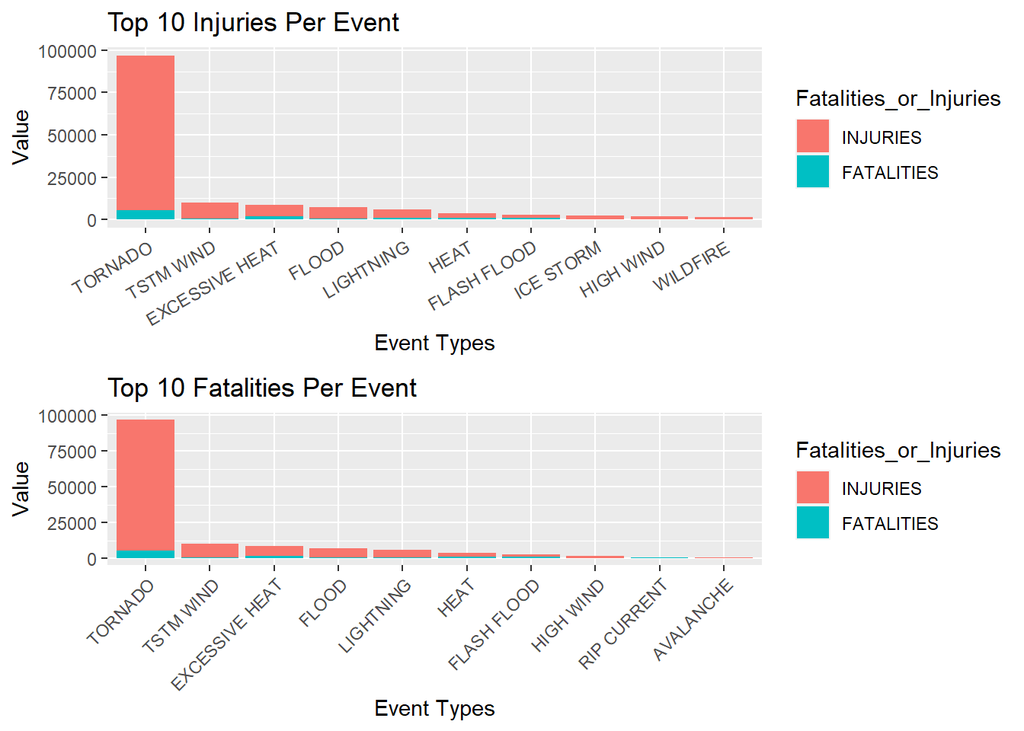

```r
components_of_the_multiplot <- list(


      "left" = ggplot(Health_Consequences_by_injuries,aes(x=reorder(EVTYPE,-value),y=value))+
                                       geom_col(aes(fill = Fatalities_or_Injuries))+
                                       xlab("Event Types")+
                                       ylab("Value")+
                                       ggtitle("Top 10 Injuries Per Event")+
                                       theme(axis.text.x = element_text(angle=30, hjust=1)),



      "Right" = ggplot(Health_Consequences_by_fatalities,aes(x=reorder(EVTYPE,-value),y=value))+
                                        geom_col(aes(fill = Fatalities_or_Injuries))+
                                        xlab("Event Types")+
                                        ylab("Value")+
                                        ggtitle("Top 10 Fatalities Per Event")+
                                        theme(axis.text.x = element_text(angle=45, hjust=1))




)


multiplot <- grid.arrange(grobs = components_of_the_multiplot,ncol=1,nrow=2)
```

BETTER VIEW!!

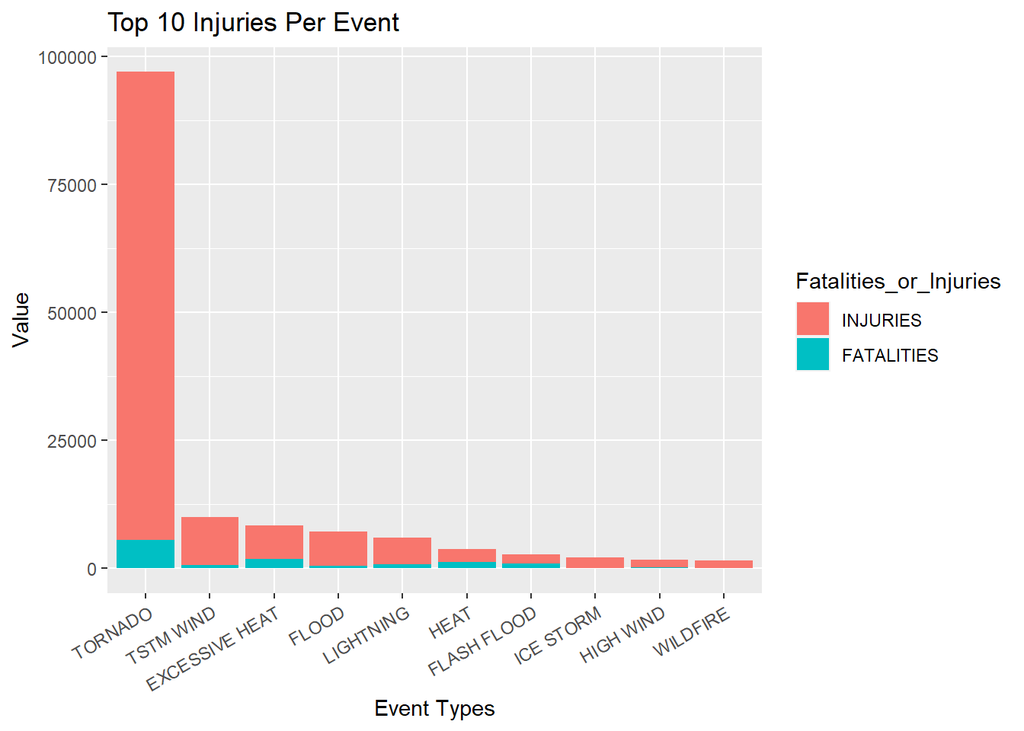

```r
I <-  ggplot(Health_Consequences_by_injuries,aes(x=reorder(EVTYPE,-value),y=value))+
                                       geom_col(aes(fill = Fatalities_or_Injuries))+
                                       xlab("Event Types")+
                                       ylab("Value")+
                                       ggtitle("Top 10 Injuries Per Event")+
                                       theme(axis.text.x = element_text(angle=30, hjust=1))
print(I)
```

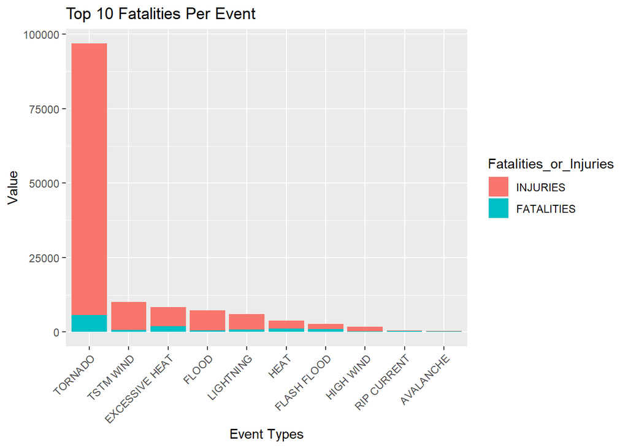

```r
f <-  ggplot(Health_Consequences_by_fatalities,aes(x=reorder(EVTYPE,-value),y=value))+
                                        geom_col(aes(fill = Fatalities_or_Injuries))+
                                        xlab("Event Types")+
                                        ylab("Value")+
                                        ggtitle("Top 10 Fatalities Per Event")+
                                        theme(axis.text.x = element_text(angle=45, hjust=1))

print(f)
```

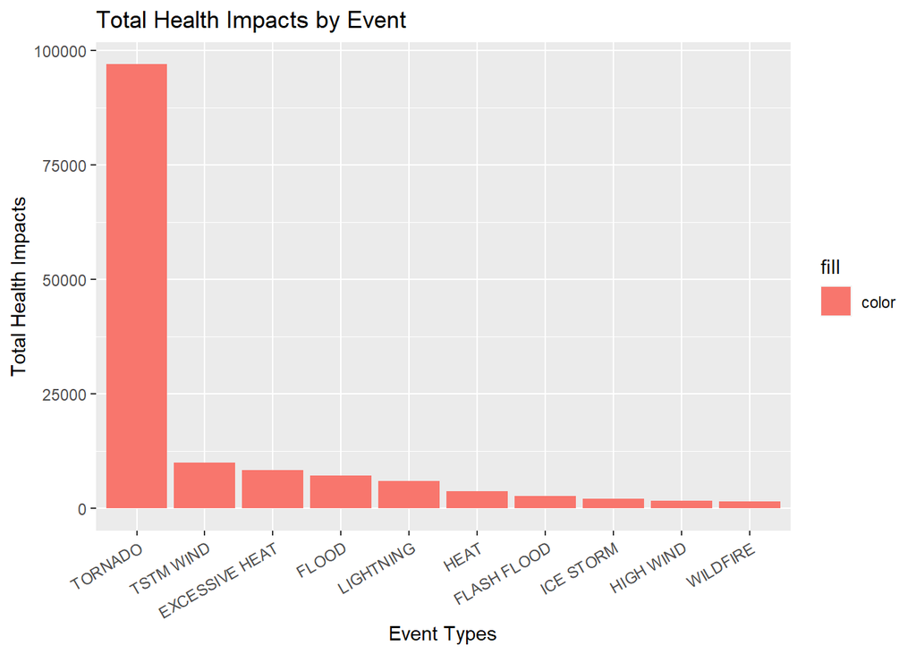

```r
     h <- ggplot(health_impact[1:10,],aes(x=reorder(EVTYPE,-total_health_impacts),y=total_health_impacts))+
                                     geom_col(aes(fill='color'))+
                                     xlab("Event Types")+
                                     ylab("Total Health Impacts")+
                                     ggtitle("Total Health Impacts by Event")+
                                     theme(axis.text.x = element_text(angle=30, hjust=1))

print(h)
```

## Across the United States, which types of events have the greatest economic consequences?

plot ECONOMIC COST

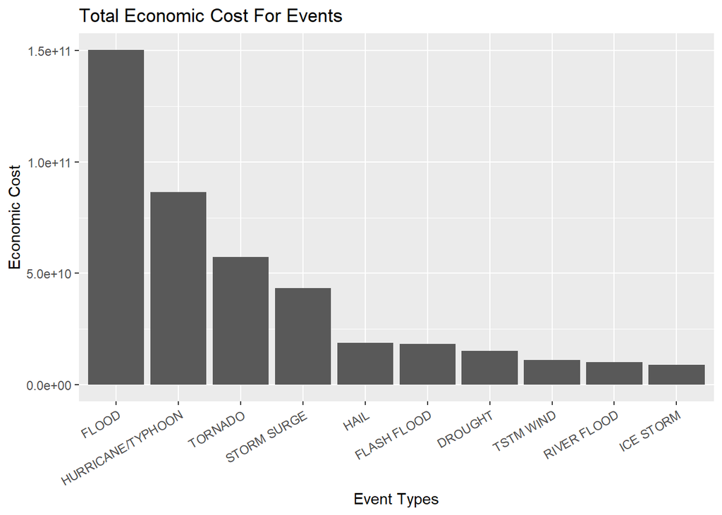

```r
g <-  ggplot(economic_cost[1:10,],aes(x=reorder(EVTYPE,-total_economic_cost),y=total_economic_cost))+
            geom_col()+
            xlab("Event Types")+
            ylab("Economic Cost")+
            ggtitle("Total Economic Cost For Events")+
            theme(axis.text.x = element_text(angle=30, hjust=1))
print(g)
```